# HEART DISEASE ANALYSIS AND PREDICTION

- 1. About Heart Disease
  - 1.1 About the Dataset
- 2. Importing necessary libraries
- 3. Data Importing
- 4. Data Analysis
- 5. Data Cleaning
  - 5.1 Finding and removing Duplicates
  - 5.2 Finding Null values
  - 5.3 Outliers Detection and Removal using Z-Score
- 6. Exploratory Data Analysis
- 7. Feature Engineering
  - 7.1 Feature Encoding
- 8. Load Data
- 9. Balancing the Imabalanced Dataset
- 10. Feature Scaling
- 11. Finding the best model and hyperparameter tuning using GridSearchCV
- 12. Model Building
  - 12.1 KNeighborsClassifier seems to have higher accuracy hence we train the model using KNN
  - 12.2 Predict the model
  - 12.3 evaluate the model

# 1. About Heart Disease

```
Cardiovascular disease or heart disease describes a range of conditions that affect your heart. Diseases under the heart disease umbrella include blood vessel diseases, such as coronary artery disease. From WHO statistics every year 17.9 million dying from heart disease. The medical study says that human life style is the main reason behind this heart problem. Apart from this there are many key factors which warns that the person may/maynot getting chance of heart disease.

From the dataset if we create suitable machine learning technique which classify the heart disease more accurately, it is very helpful to the health organisation as well as patients.
```

## 1.1 About the Data set

[output not shown]

# 2. Importing necessary libraries

```python
# Import libraries

import numpy as np
import pandas as pd
import matplotlib.pyplot as plt
import seaborn as sns
import scipy.stats as stats
%matplotlib inline



from sklearn.model_selection import GridSearchCV, train_test_split
from sklearn.linear_model import LogisticRegression
from sklearn.tree import DecisionTreeClassifier
from sklearn.ensemble import RandomForestClassifier
from sklearn.svm import SVC
from sklearn.neighbors import KNeighborsClassifier
from sklearn.ensemble import GradientBoostingClassifier
from sklearn.ensemble import AdaBoostClassifier
from xgboost import XGBClassifier
from sklearn.metrics import accuracy_score, f1_score, precision_score, recall_score, classification_report, confusion_matrix, ConfusionMatrixDisplay

import warnings
warnings.filterwarnings("ignore")
```

# 3. Data Importing

```python
df=pd.read_csv("heart.csv")
```

# 4. Data Analysis

```python
df.shape
```

```
(1025, 14)
```

```python
df.head()
```

|  | age | sex | cp | trestbps | chol | fbs | restecg | thalach | exang | oldpeak | slope | ca | thal | target |
| --- | --- | --- | --- | --- | --- | --- | --- | --- | --- | --- | --- | --- | --- | --- |
| 0 | 52 | 1 | 0 | 125 | 212 | 0 | 1 | 168 | 0 | 1.0 | 2 | 2 | 3 | 0 |
| 1 | 53 | 1 | 0 | 140 | 203 | 1 | 0 | 155 | 1 | 3.1 | 0 | 0 | 3 | 0 |
| 2 | 70 | 1 | 0 | 145 | 174 | 0 | 1 | 125 | 1 | 2.6 | 0 | 0 | 3 | 0 |
| 3 | 61 | 1 | 0 | 148 | 203 | 0 | 1 | 161 | 0 | 0.0 | 2 | 1 | 3 | 0 |
| 4 | 62 | 0 | 0 | 138 | 294 | 1 | 1 | 106 | 0 | 1.9 | 1 | 3 | 2 | 0 |

```python
df.tail()
```

|  | age | sex | cp | trestbps | chol | fbs | restecg | thalach | exang | oldpeak | slope | ca | thal | target |
| --- | --- | --- | --- | --- | --- | --- | --- | --- | --- | --- | --- | --- | --- | --- |
| 1020 | 59 | 1 | 1 | 140 | 221 | 0 | 1 | 164 | 1 | 0.0 | 2 | 0 | 2 | 1 |
| 1021 | 60 | 1 | 0 | 125 | 258 | 0 | 0 | 141 | 1 | 2.8 | 1 | 1 | 3 | 0 |
| 1022 | 47 | 1 | 0 | 110 | 275 | 0 | 0 | 118 | 1 | 1.0 | 1 | 1 | 2 | 0 |
| 1023 | 50 | 0 | 0 | 110 | 254 | 0 | 0 | 159 | 0 | 0.0 | 2 | 0 | 2 | 1 |
| 1024 | 54 | 1 | 0 | 120 | 188 | 0 | 1 | 113 | 0 | 1.4 | 1 | 1 | 3 | 0 |

```python
df.describe()
```

|  | age | sex | cp | trestbps | chol | fbs | restecg | thalach | exang | oldpeak | slope | ca | thal | target |
| --- | --- | --- | --- | --- | --- | --- | --- | --- | --- | --- | --- | --- | --- | --- |
| count | 1025.000000 | 1025.000000 | 1025.000000 | 1025.000000 | 1025.00000 | 1025.000000 | 1025.000000 | 1025.000000 | 1025.000000 | 1025.000000 | 1025.000000 | 1025.000000 | 1025.000000 | 1025.000000 |
| mean | 54.434146 | 0.695610 | 0.942439 | 131.611707 | 246.00000 | 0.149268 | 0.529756 | 149.114146 | 0.336585 | 1.071512 | 1.385366 | 0.754146 | 2.323902 | 0.513171 |
| std | 9.072290 | 0.460373 | 1.029641 | 17.516718 | 51.59251 | 0.356527 | 0.527878 | 23.005724 | 0.472772 | 1.175053 | 0.617755 | 1.030798 | 0.620660 | 0.500070 |
| min | 29.000000 | 0.000000 | 0.000000 | 94.000000 | 126.00000 | 0.000000 | 0.000000 | 71.000000 | 0.000000 | 0.000000 | 0.000000 | 0.000000 | 0.000000 | 0.000000 |
| 25% | 48.000000 | 0.000000 | 0.000000 | 120.000000 | 211.00000 | 0.000000 | 0.000000 | 132.000000 | 0.000000 | 0.000000 | 1.000000 | 0.000000 | 2.000000 | 0.000000 |
| 50% | 56.000000 | 1.000000 | 1.000000 | 130.000000 | 240.00000 | 0.000000 | 1.000000 | 152.000000 | 0.000000 | 0.800000 | 1.000000 | 0.000000 | 2.000000 | 1.000000 |
| 75% | 61.000000 | 1.000000 | 2.000000 | 140.000000 | 275.00000 | 0.000000 | 1.000000 | 166.000000 | 1.000000 | 1.800000 | 2.000000 | 1.000000 | 3.000000 | 1.000000 |
| max | 77.000000 | 1.000000 | 3.000000 | 200.000000 | 564.00000 | 1.000000 | 2.000000 | 202.000000 | 1.000000 | 6.200000 | 2.000000 | 4.000000 | 3.000000 | 1.000000 |

```python
df.info()
```

```
<class 'pandas.core.frame.DataFrame'>
RangeIndex: 1025 entries, 0 to 1024
Data columns (total 14 columns):
 #   Column    Non-Null Count  Dtype
---  ------    --------------  -----
 0   age       1025 non-null   int64
 1   sex       1025 non-null   int64
 2   cp        1025 non-null   int64
 3   trestbps  1025 non-null   int64
 4   chol      1025 non-null   int64
 5   fbs       1025 non-null   int64
 6   restecg   1025 non-null   int64
 7   thalach   1025 non-null   int64
 8   exang     1025 non-null   int64
 9   oldpeak   1025 non-null   float64
 10  slope     1025 non-null   int64
 11  ca        1025 non-null   int64
 12  thal      1025 non-null   int64
 13  target    1025 non-null   int64
dtypes: float64(1), int64(13)
memory usage: 112.2 KB
```

```python
# Look at the correlation matrix
df.corr()
```

|  | age | sex | cp | trestbps | chol | fbs | restecg | thalach | exang | oldpeak | slope | ca | thal | target |
| --- | --- | --- | --- | --- | --- | --- | --- | --- | --- | --- | --- | --- | --- | --- |
| age | 1.000000 | -0.103240 | -0.071966 | 0.271121 | 0.219823 | 0.121243 | -0.132696 | -0.390227 | 0.088163 | 0.208137 | -0.169105 | 0.271551 | 0.072297 | -0.229324 |
| sex | -0.103240 | 1.000000 | -0.041119 | -0.078974 | -0.198258 | 0.027200 | -0.055117 | -0.049365 | 0.139157 | 0.084687 | -0.026666 | 0.111729 | 0.198424 | -0.279501 |
| cp | -0.071966 | -0.041119 | 1.000000 | 0.038177 | -0.081641 | 0.079294 | 0.043581 | 0.306839 | -0.401513 | -0.174733 | 0.131633 | -0.176206 | -0.163341 | 0.434854 |
| trestbps | 0.271121 | -0.078974 | 0.038177 | 1.000000 | 0.127977 | 0.181767 | -0.123794 | -0.039264 | 0.061197 | 0.187434 | -0.120445 | 0.104554 | 0.059276 | -0.138772 |
| chol | 0.219823 | -0.198258 | -0.081641 | 0.127977 | 1.000000 | 0.026917 | -0.147410 | -0.021772 | 0.067382 | 0.064880 | -0.014248 | 0.074259 | 0.100244 | -0.099966 |
| fbs | 0.121243 | 0.027200 | 0.079294 | 0.181767 | 0.026917 | 1.000000 | -0.104051 | -0.008866 | 0.049261 | 0.010859 | -0.061902 | 0.137156 | -0.042177 | -0.041164 |
| restecg | -0.132696 | -0.055117 | 0.043581 | -0.123794 | -0.147410 | -0.104051 | 1.000000 | 0.048411 | -0.065606 | -0.050114 | 0.086086 | -0.078072 | -0.020504 | 0.134468 |
| thalach | -0.390227 | -0.049365 | 0.306839 | -0.039264 | -0.021772 | -0.008866 | 0.048411 | 1.000000 | -0.380281 | -0.349796 | 0.395308 | -0.207888 | -0.098068 | 0.422895 |
| exang | 0.088163 | 0.139157 | -0.401513 | 0.061197 | 0.067382 | 0.049261 | -0.065606 | -0.380281 | 1.000000 | 0.310844 | -0.267335 | 0.107849 | 0.197201 | -0.438029 |
| oldpeak | 0.208137 | 0.084687 | -0.174733 | 0.187434 | 0.064880 | 0.010859 | -0.050114 | -0.349796 | 0.310844 | 1.000000 | -0.575189 | 0.221816 | 0.202672 | -0.438441 |
| slope | -0.169105 | -0.026666 | 0.131633 | -0.120445 | -0.014248 | -0.061902 | 0.086086 | 0.395308 | -0.267335 | -0.575189 | 1.000000 | -0.073440 | -0.094090 | 0.345512 |
| ca | 0.271551 | 0.111729 | -0.176206 | 0.104554 | 0.074259 | 0.137156 | -0.078072 | -0.207888 | 0.107849 | 0.221816 | -0.073440 | 1.000000 | 0.149014 | -0.382085 |
| thal | 0.072297 | 0.198424 | -0.163341 | 0.059276 | 0.100244 | -0.042177 | -0.020504 | -0.098068 | 0.197201 | 0.202672 | -0.094090 | 0.149014 | 1.000000 | -0.337838 |
| target | -0.229324 | -0.279501 | 0.434854 | -0.138772 | -0.099966 | -0.041164 | 0.134468 | 0.422895 | -0.438029 | -0.438441 | 0.345512 | -0.382085 | -0.337838 | 1.000000 |

# 5. Data Cleaning

## 5.1 Finding and removing Duplicates

```python
df.duplicated().sum()
```

```
723
```

```python
df=df.drop_duplicates(keep="first")
```

```python
df.shape
```

```
(302, 14)
```

there are 723 duplicates when removed total rows have reduced to 302

## 5.2 Finding Null values

```python
df.isna().sum()
```

```
age         0
sex         0
cp          0
trestbps    0
chol        0
fbs         0
restecg     0
thalach     0
exang       0
oldpeak     0
slope       0
ca          0
thal        0
target      0
dtype: int64
```

As we can see there are no null values

## 5.3 Outliers Detection and Removal using Z-Score

```python
#find absolute value of z-score for each observation
z = np.abs(stats.zscore(df))

#only keep rows in dataframe with all z-scores less than absolute value of 3
df= df[(z<3).all(axis=1)]

df.shape
```

```
(287, 14)
```

15 outliers were removed and cleaned

# 6. Exploratory Data Analysis

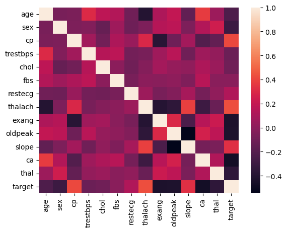

```python
sns.heatmap(df.corr())
```

slope, thalach(maximum heart rate) and (cp)chest pain are highly correleated to target

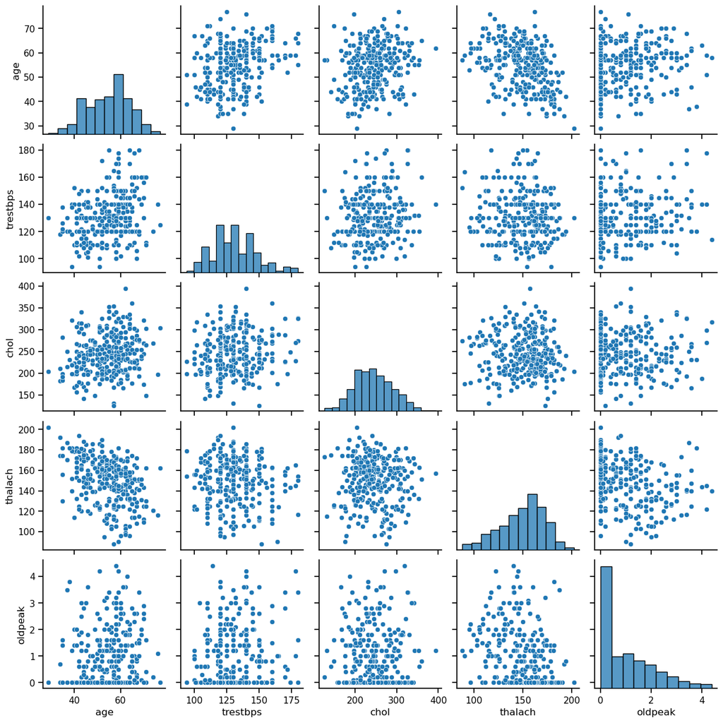

```
target      1.000000
thalach     0.431519
cp          0.408570
slope       0.323948
restecg     0.130079
fbs        -0.011438
chol       -0.099821
trestbps   -0.119281
age        -0.226750
sex        -0.302926
thal       -0.354579
oldpeak    -0.424443
exang      -0.429082
ca         -0.463258
Name: target, dtype: float64
```

```python
categorical = ["sex", "cp", "fbs", "restecg", "exang",  "slope", "ca", "thal", "target"]
numerical = ["age","trestbps", "chol", "thalach",  "oldpeak"]

# pandas trick: give me all rows of numerical columns
sns.set_context("notebook", font_scale=1, rc={"lines.linewidth": 2.5})
df_to_plot = df.loc[:,numerical]
sns.pairplot(df_to_plot);

plt.show()

# Look at correlation coefficients too
corr_matrix = df.corr()
corr_matrix['target'].sort_values(ascending=False)
```

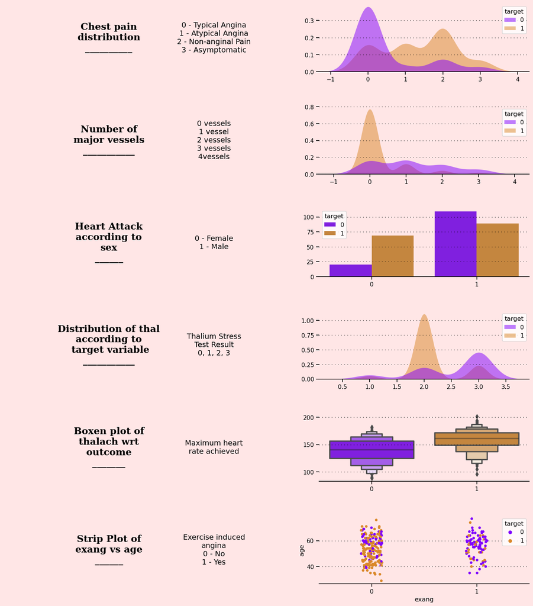

```python
fig = plt.figure(figsize=(18,20))
gs = fig.add_gridspec(6,2)
gs.update(wspace=0.5, hspace=0.5)
ax0 = fig.add_subplot(gs[0,0])
ax1 = fig.add_subplot(gs[0,1])
ax2 = fig.add_subplot(gs[1,0])
ax3 = fig.add_subplot(gs[1,1])
ax4 = fig.add_subplot(gs[2,0])
ax5 = fig.add_subplot(gs[2,1])
ax6 = fig.add_subplot(gs[3,0])
ax7 = fig.add_subplot(gs[3,1])
ax8 = fig.add_subplot(gs[4,0])
ax9 = fig.add_subplot(gs[4,1])
ax10 = fig.add_subplot(gs[5,0])
ax11 = fig.add_subplot(gs[5,1])

background_color = "#ffe6e6"
color_palette = ["#800000","#8000ff","#6aac90","#5833ff","#da8829"]
fig.patch.set_facecolor(background_color)
ax0.set_facecolor(background_color)
ax1.set_facecolor(background_color)
ax2.set_facecolor(background_color)
ax3.set_facecolor(background_color)
ax4.set_facecolor(background_color)
ax5.set_facecolor(background_color)
ax6.set_facecolor(background_color)
ax7.set_facecolor(background_color)
ax8.set_facecolor(background_color)
ax9.set_facecolor(background_color)
ax10.set_facecolor(background_color)
ax11.set_facecolor(background_color)

# Cp title
# 0 = Typical Angina, 1 = Atypical Angina, 2 = Non-anginal Pain, 3 = Asymptomatic
ax0.text(0.5,0.5,"Chest pain\ndistribution\n__________",
        horizontalalignment = 'center',
        verticalalignment = 'center',
        fontsize = 18,
        fontweight='bold',
        fontfamily='serif',
        color='#000000')
ax0.spines["bottom"].set_visible(False)
ax0.set_xticklabels([])
ax0.set_yticklabels([])
ax0.tick_params(left=False, bottom=False)
ax0.text(1,.5,"0 - Typical Angina\n1 - Atypical Angina\n2 - Non-anginal Pain\n3 - Asymptomatic",
        horizontalalignment = 'center',
         verticalalignment = 'center',
        fontsize = 14
        )

# Cp
ax1.grid(color='#000000', linestyle=':', axis='y', zorder=0,  dashes=(1,5))
sns.kdeplot(ax=ax1, data=df, x='cp',hue="target", fill=True,palette=["#8000ff","#da8829"], alpha=.5, linewidth=0)
ax1.set_xlabel("")
ax1.set_ylabel("")

# Ca title
ax2.text(0.5,0.5,"Number of\nmajor vessels\n___________",
        horizontalalignment = 'center',
        verticalalignment = 'center',
        fontsize = 18,
        fontweight='bold',
        fontfamily='serif',
        color='#000000')
ax2.text(1,.5,"0 vessels\n1 vessel\n2 vessels\n3 vessels\n4vessels",
        horizontalalignment = 'center',
         verticalalignment = 'center',
        fontsize = 14
        )

ax2.spines["bottom"].set_visible(False)
ax2.set_xticklabels([])
ax2.set_yticklabels([])
ax2.tick_params(left=False, bottom=False)

# Ca
ax3.grid(color='#000000', linestyle=':', axis='y', zorder=0,  dashes=(1,5))
sns.kdeplot(ax=ax3, data=df, x='ca',hue="target", fill=True,palette=["#8000ff","#da8829"], alpha=.5, linewidth=0)
ax3.set_xlabel("")
ax3.set_ylabel("")

# Sex title
ax4.text(0.5,0.5,"Heart Attack\naccording to\nsex\n______",
        horizontalalignment = 'center',
        verticalalignment = 'center',
        fontsize = 18,
        fontweight='bold',
        fontfamily='serif',
        color='#000000')
ax4.text(1,.5,"0 - Female\n1 - Male",
        horizontalalignment = 'center',
         verticalalignment = 'center',
        fontsize = 14
        )
ax4.spines["bottom"].set_visible(False)
ax4.set_xticklabels([])
ax4.set_yticklabels([])
ax4.tick_params(left=False, bottom=False)

# Sex
ax5.grid(color='#000000', linestyle=':', axis='y', zorder=0,  dashes=(1,5))
sns.countplot(ax=ax5,data=df,x='sex',palette=["#8000ff","#da8829"], hue='target')
ax5.set_xlabel("")
ax5.set_ylabel("")

# Thal title
ax6.text(0.5,0.5,"Distribution of thal\naccording to\n target variable\n___________",
        horizontalalignment = 'center',
        verticalalignment = 'center',
        fontsize = 18,
        fontweight='bold',
        fontfamily='serif',
        color='#000000')
ax6.text(1,.5,"Thalium Stress\nTest Result\n0, 1, 2, 3",
        horizontalalignment = 'center',
         verticalalignment = 'center',
        fontsize = 14
        )
ax6.spines["bottom"].set_visible(False)
ax6.set_xticklabels([])
ax6.set_yticklabels([])
ax6.tick_params(left=False, bottom=False)

# Thal
ax7.grid(color='#000000', linestyle=':', axis='y', zorder=0,  dashes=(1,5))
sns.kdeplot(ax=ax7, data=df, x='thal',hue="target", fill=True,palette=["#8000ff","#da8829"], alpha=.5, linewidth=0)
ax7.set_xlabel("")
ax7.set_ylabel("")

# Thalach title
ax8.text(0.5,0.5,"Boxen plot of\nthalach wrt\noutcome\n_______",
        horizontalalignment = 'center',
        verticalalignment = 'center',
        fontsize = 18,
        fontweight='bold',
        fontfamily='serif',
        color='#000000')
ax8.text(1,.5,"Maximum heart\nrate achieved",
        horizontalalignment = 'center',
         verticalalignment = 'center',
        fontsize = 14
        )

ax8.spines["bottom"].set_visible(False)
ax8.set_xticklabels([])
ax8.set_yticklabels([])
ax8.tick_params(left=False, bottom=False)

# Thalachh
ax9.grid(color='#000000', linestyle=':', axis='y', zorder=0,  dashes=(1,5))
sns.boxenplot(ax=ax9, data=df,x='target',y='thalach',palette=["#8000ff","#da8829"])
ax9.set_xlabel("")
ax9.set_ylabel("")



# Exang title
ax10.text(0.5,0.5,"Strip Plot of\nexang vs age\n______",
        horizontalalignment = 'center',
        verticalalignment = 'center',
        fontsize = 18,
        fontweight='bold',
        fontfamily='serif',
        color='#000000')
ax10.text(1,.5,"Exercise induced\nangina\n0 - No\n1 - Yes",
        horizontalalignment = 'center',
         verticalalignment = 'center',
        fontsize = 14
        )
ax10.spines["bottom"].set_visible(False)
ax10.set_xticklabels([])
ax10.set_yticklabels([])
ax10.tick_params(left=False, bottom=False)


# Exang
ax11.grid(color='#000000', linestyle=':', axis='y', zorder=0,  dashes=(1,5))
sns.stripplot(ax=ax11, data=df,x='exang',y='age',hue='target',palette=["#8000ff","#da8829"])
ax9.set_xlabel("")
ax9.set_ylabel("")

for i in ["top","left","right"]:
    ax0.spines[i].set_visible(False)
    ax1.spines[i].set_visible(False)
    ax2.spines[i].set_visible(False)
    ax3.spines[i].set_visible(False)
    ax4.spines[i].set_visible(False)
    ax5.spines[i].set_visible(False)
    ax6.spines[i].set_visible(False)
    ax7.spines[i].set_visible(False)
    ax8.spines[i].set_visible(False)
    ax9.spines[i].set_visible(False)
    ax10.spines[i].set_visible(False)
    ax11.spines[i].set_visible(False)
```

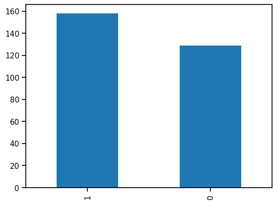

```python
#finging the values
df.target.value_counts().plot.bar()
```

```python
df.target.value_counts()
```

```
1    158
0    129
Name: target, dtype: int64
```

target class has 158 heart disease patients and 129 not heart disease patients so data balancing is required

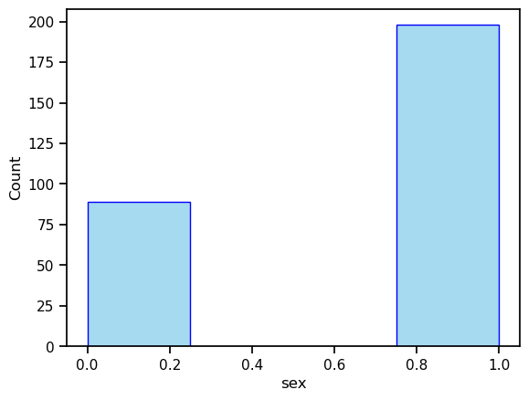

```python
sns.histplot(data=df, x='sex', bins=4, color='skyblue', edgecolor='blue')
```

```python
df.sex.value_counts()
```

```
1    198
0     89
Name: sex, dtype: int64
```

198 male patients and 89 female patients are there in the dataset

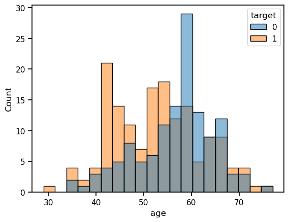

```python
sns.histplot(data=df, x='age', bins=20, hue='target')
```

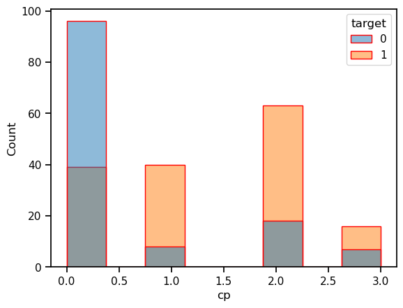

```python
sns.histplot(data=df, x='cp', bins=8, color='orange', edgecolor='red', hue = 'target')
```

patients with chest pain index at 2.0 is more likely to have heart disease

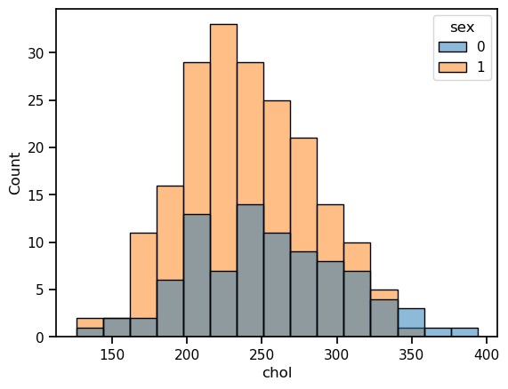

```python
sns.histplot(data=df, x='chol', hue='sex')
```

more number of male patients are having cholestrol than female patients

# 7. Feature Engineering

## 7.1 Feature Encoding

```python
cat_cols = ['sex','exang','ca','cp','fbs','restecg','slope','thal']
df = pd.get_dummies(df, columns = cat_cols, drop_first = True)
```

```python
df
```

|  | age | trestbps | chol | thalach | oldpeak | target | sex_1 | exang_1 | ca_1 | ca_2 | ... | cp_1 | cp_2 | cp_3 | fbs_1 | restecg_1 | restecg_2 | slope_1 | slope_2 | thal_2 | thal_3 |
| --- | --- | --- | --- | --- | --- | --- | --- | --- | --- | --- | --- | --- | --- | --- | --- | --- | --- | --- | --- | --- | --- |
| 0 | 52 | 125 | 212 | 168 | 1.0 | 0 | 1 | 0 | 0 | 1 | ... | 0 | 0 | 0 | 0 | 1 | 0 | 0 | 1 | 0 | 1 |
| 1 | 53 | 140 | 203 | 155 | 3.1 | 0 | 1 | 1 | 0 | 0 | ... | 0 | 0 | 0 | 1 | 0 | 0 | 0 | 0 | 0 | 1 |
| 2 | 70 | 145 | 174 | 125 | 2.6 | 0 | 1 | 1 | 0 | 0 | ... | 0 | 0 | 0 | 0 | 1 | 0 | 0 | 0 | 0 | 1 |
| 3 | 61 | 148 | 203 | 161 | 0.0 | 0 | 1 | 0 | 1 | 0 | ... | 0 | 0 | 0 | 0 | 1 | 0 | 0 | 1 | 0 | 1 |
| 4 | 62 | 138 | 294 | 106 | 1.9 | 0 | 0 | 0 | 0 | 0 | ... | 0 | 0 | 0 | 1 | 1 | 0 | 1 | 0 | 1 | 0 |
| ... | ... | ... | ... | ... | ... | ... | ... | ... | ... | ... | ... | ... | ... | ... | ... | ... | ... | ... | ... | ... | ... |
| 723 | 68 | 120 | 211 | 115 | 1.5 | 1 | 0 | 0 | 0 | 0 | ... | 0 | 1 | 0 | 0 | 0 | 0 | 1 | 0 | 1 | 0 |
| 733 | 44 | 108 | 141 | 175 | 0.6 | 1 | 0 | 0 | 0 | 0 | ... | 0 | 1 | 0 | 0 | 1 | 0 | 1 | 0 | 1 | 0 |
| 739 | 52 | 128 | 255 | 161 | 0.0 | 0 | 1 | 1 | 1 | 0 | ... | 0 | 0 | 0 | 0 | 1 | 0 | 0 | 1 | 0 | 1 |
| 843 | 59 | 160 | 273 | 125 | 0.0 | 0 | 1 | 0 | 0 | 0 | ... | 0 | 0 | 1 | 0 | 0 | 0 | 0 | 1 | 1 | 0 |
| 878 | 54 | 120 | 188 | 113 | 1.4 | 0 | 1 | 0 | 1 | 0 | ... | 0 | 0 | 0 | 0 | 1 | 0 | 1 | 0 | 0 | 1 |

287 rows × 21 columns

## 8. Load Data

```python
# Load data
X_s = df.drop(["target"], axis=1)
y_s = df["target"]
```

## 9. Balancing the Imabalanced Dataset

```python
from imblearn.over_sampling import RandomOverSampler
# create an instance of RandomOverSampler
oversampler = RandomOverSampler(sampling_strategy='minority', random_state=42)

# resample the data
X, y = oversampler.fit_resample(X_s, y_s)
```

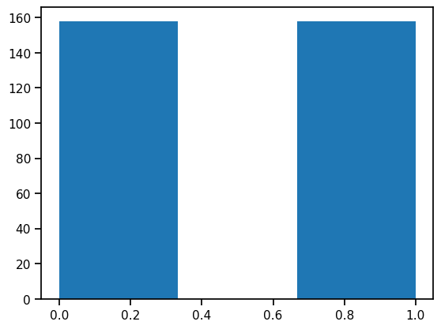

```python
import matplotlib.pyplot as plt # import the pyplot module

plt.hist(y, bins=3) # plot the histogram
plt.show() # show the plot
```

```python
y.value_counts()
```

```
0    158
1    158
Name: target, dtype: int64
```

count shows target value is balanced

# 10. Feature Scaling

```python
# Fit the scaler on the training data
from sklearn.preprocessing import StandardScaler
scaler = StandardScaler()
scaler.fit(X)
```

```
StandardScaler()
```

```python
features = X.columns
X[features] = scaler.transform(X)
```

```python
X_train, X_test, y_train, y_test = train_test_split(X,
                                                    y,
                                                    test_size=0.2,
                                                    random_state=42)
```

# 11. Finding the best model and hyperparameter tuning using GridSearchCV

```python
# Define models and parameter grids
models = [LogisticRegression(),
          DecisionTreeClassifier(),
          RandomForestClassifier(),
          SVC(),
          KNeighborsClassifier(),
          GradientBoostingClassifier(),
          AdaBoostClassifier(),
          XGBClassifier()
         ]

param_grids = [
    {  "penalty": ["l1", "l2", "elasticnet", None],
     "C": [0.001, 0.01, 0.1, 1.0, 10, 100, 1000],
     "solver": ["lbfgs", "liblinear", "newton-cg", "newton-cholesky", "sag", "saga"]},
    {"criterion": ["gini","entropy"],
     "max_depth": [2, 4, 8, 16, 32],
     "min_samples_split": [2, 4, 8, 16, 32],
     "min_samples_leaf": [2, 4, 8, 16, 32]},
    {"n_estimators": [5, 50, 250, 500],
      "max_depth": [2, 4, 8, 16, 32]},
    {"C": [0.001, 0.01, 0.1, 1.0, 10, 100, 1000],
     "kernel": ["linear", "poly", "rbf", "sigmoid"]},
    {"n_neighbors": range(2, 21),
    "weights": ["uniform", "distance"],
    "algorithm": ["ball_tree", "kd_tree", "brute"],
    "metric": ["minkowski", "euclidean", "manhattan"]},
    {"learning_rate": [0.01, 0.1, 1.0, 10, 100],
    "n_estimators": [5, 50, 250, 500],
    "max_depth": [2, 4, 8, 16, 32]},
    {"n_estimators": [5, 50, 250, 500],
    "learning_rate": [0.01, 0.1, 1.0, 10, 100]},
    {"n_estimators": [5, 50, 250, 500],
    "max_depth": [2, 4, 8, 16, 32],
    "learning_rate": [0.01, 0.1, 1.0, 10, 100],
    "eval_metric": ["auc", "aucpr", "error"]}
    ]
```

```python
my_dict = {} # create an empty dictionary
# Loop over models and parameter grids
for model, param_grid in zip(models, param_grids):
    # Create GridSearchCV object
    grid = GridSearchCV(model, param_grid, scoring='accuracy', cv=5)

    # Fit on data
    grid.fit(X_train, y_train)

    # Print best score and best parameters
    print(f'Best score for {model.__class__.__name__}: {grid.best_score_:.4f}')
    print(f'Best parameters for {model.__class__.__name__}: {grid.best_params_}')




    my_dict.update({model.__class__.__name__ : grid.best_score_} )
```

```
Best score for LogisticRegression: 0.8490
Best parameters for LogisticRegression: {'C': 1.0, 'penalty': 'l1', 'solver': 'saga'}
Best score for DecisionTreeClassifier: 0.7815
Best parameters for DecisionTreeClassifier: {'criterion': 'gini', 'max_depth': 32, 'min_samples_leaf': 2, 'min_samples_split': 2}
Best score for RandomForestClassifier: 0.8449
Best parameters for RandomForestClassifier: {'max_depth': 32, 'n_estimators': 50}
Best score for SVC: 0.8649
Best parameters for SVC: {'C': 1.0, 'kernel': 'rbf'}
Best score for KNeighborsClassifier: 0.8770
Best parameters for KNeighborsClassifier: {'algorithm': 'ball_tree', 'metric': 'manhattan', 'n_neighbors': 7, 'weights': 'distance'}
Best score for GradientBoostingClassifier: 0.8292
Best parameters for GradientBoostingClassifier: {'learning_rate': 0.1, 'max_depth': 2, 'n_estimators': 50}
Best score for AdaBoostClassifier: 0.8292
Best parameters for AdaBoostClassifier: {'learning_rate': 0.1, 'n_estimators': 250}
Best score for XGBClassifier: 0.8449
Best parameters for XGBClassifier: {'eval_metric': 'auc', 'learning_rate': 0.1, 'max_depth': 2, 'n_estimators': 250}
```

```python
for k, v in my_dict.items():
    my_dict[k] = (round(v, 4))

df3 = pd.DataFrame(list(my_dict.items()), columns=['Model', 'Accuracy'])
print(df3)
```

```
                        Model  Accuracy
0          LogisticRegression    0.8490
1      DecisionTreeClassifier    0.7815
2      RandomForestClassifier    0.8449
3                         SVC    0.8649
4        KNeighborsClassifier    0.8770
5  GradientBoostingClassifier    0.8292
6          AdaBoostClassifier    0.8292
7               XGBClassifier    0.8449
```

# 12. Model building

## 12.1 KNeighborsClassifier seems to have higher accuracy hence we train the model using KNN

```python
Knc =  KNeighborsClassifier(algorithm = 'ball_tree', metric = 'manhattan', n_neighbors = 7, weights = 'distance')

Knc.fit(X_train,y_train)
```

```
KNeighborsClassifier(algorithm='ball_tree', metric='manhattan', n_neighbors=7,
                     weights='distance')
```

## 12.2 predict using model

```python
y_pred =Knc.predict(X_test)
```

```python
y_pred
```

```
array([1, 0, 1, 1, 0, 0, 0, 0, 0, 0, 0, 1, 1, 0, 1, 0, 1, 1, 1, 1, 1, 1,
       0, 1, 0, 1, 0, 1, 1, 0, 1, 1, 1, 0, 1, 1, 0, 0, 1, 1, 1, 1, 1, 1,
       1, 0, 1, 0, 0, 1, 1, 0, 0, 0, 1, 1, 0, 0, 0, 1, 1, 0, 1, 0],
      dtype=int64)
```

## 12.3 evaluate the model

```python
score=accuracy_score(y_pred,y_test)
score
```

```
0.875
```

```python
print(classification_report(y_test, y_pred))
```

```
              precision    recall  f1-score   support

           0       0.86      0.86      0.86        28
           1       0.89      0.89      0.89        36

    accuracy                           0.88        64
   macro avg       0.87      0.87      0.87        64
weighted avg       0.88      0.88      0.88        64
```

```
<sklearn.metrics._plot.confusion_matrix.ConfusionMatrixDisplay at 0x21be3b50580>
```

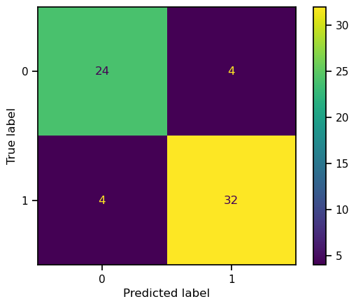

```python
ConfusionMatrixDisplay.from_predictions(y_test, y_pred)
```